## 1. Checking homocedasticity

Studentized Breusch-Pagan test

The test is implemented in the library lmtest. The test is used to test heterokedsticity in a linear regression model. It test whether the variance of the rrors from a regression is dependent on the values of the independent variables. If this is the case, we have heterokedasticity.

The null hypothesis is that there is homokedasticity. The test is calculated as: $BP=nR^2$, where $R^2$ is the coefficient of Determination of the regression between the squared residuals $r_i^2$ of a LS regression between Y and variables $X_1, X_2,\ldots,X_p$ (including the intercept), and the covariates (or a sub-set) $X_1, X_2,\ldots,X_p$.

Under the null hypothesis of homokedasticity, the statistic $BP=nR^2$ has an asymtotic $\chi^2_{p-1}$ distribution.

```r
library(faraway)
attach(savings)
n=50; p=5;
g = lm(sr ~., data=savings);
library(lmtest)
bptest(g)
```

```
##
##  studentized Breusch-Pagan test
##
## data:  g
## BP = 4.9852, df = 4, p-value = 0.2888
```

```r
tmp.fit = lm(g$res^2 ~ pop15 + pop75 + dpi + ddpi)
summary(tmp.fit)
```

```
##
## Call:
## lm(formula = g$res^2 ~ pop15 + pop75 + dpi + ddpi)
##
## Residuals:
##     Min      1Q  Median      3Q     Max
## -20.790 -10.730  -6.187   3.940  74.449
##
## Coefficients:
##              Estimate Std. Error t value Pr(>|t|)
## (Intercept) 12.509324  36.166643   0.346    0.731
## pop15        0.231033   0.711294   0.325    0.747
## pop75       -3.787945   5.328717  -0.711    0.481
## dpi          0.001231   0.004579   0.269    0.789
## ddpi        -0.074270   0.964821  -0.077    0.939
##
## Residual standard error: 18.7 on 45 degrees of freedom
## Multiple R-squared:  0.0997, Adjusted R-squared:  0.01968
## F-statistic: 1.246 on 4 and 45 DF,  p-value: 0.3053
```

```r
summary(tmp.fit)$r.sq*50 #Compare this value with the BP statistic.
```

```
## [1] 4.985161
```

```r
# We fail to reject the null hypotheis of homocedasticity
```

## 2. Checking Model Structure

Partial regression plots (Added Variable plots) to check the model structure $E[Y]=X\beta$.

```r
g = lm(sr ~., data=savings)
summary(g)
```

```
##
## Call:
## lm(formula = sr ~ ., data = savings)
##
## Residuals:
##     Min      1Q  Median      3Q     Max
## -8.2422 -2.6857 -0.2488  2.4280  9.7509
##
## Coefficients:
##               Estimate Std. Error t value Pr(>|t|)
## (Intercept) 28.5660865  7.3545161   3.884 0.000334 ***
## pop15       -0.4611931  0.1446422  -3.189 0.002603 **
## pop75       -1.6914977  1.0835989  -1.561 0.125530
## dpi         -0.0003369  0.0009311  -0.362 0.719173
## ddpi         0.4096949  0.1961971   2.088 0.042471 *
## ---
## Signif. codes:  0 '***' 0.001 '**' 0.01 '*' 0.05 '.' 0.1 ' ' 1
##
## Residual standard error: 3.803 on 45 degrees of freedom
## Multiple R-squared:  0.3385, Adjusted R-squared:  0.2797
## F-statistic: 5.756 on 4 and 45 DF,  p-value: 0.0007904
```

```r
# Remove the effect of each variable and fit a regression on the residuals
r.ypop15 = update(g, ~. - pop15)$res;
r.pop15 = lm(pop15 ~., data=savings[,-1])$res;
tmp1=lm(r.ypop15 ~ r.pop15); summary(tmp1)
```

```
##
## Call:
## lm(formula = r.ypop15 ~ r.pop15)
##
## Residuals:
##     Min      1Q  Median      3Q     Max
## -8.2422 -2.6857 -0.2488  2.4280  9.7509
##
## Coefficients:
##               Estimate Std. Error t value Pr(>|t|)
## (Intercept)  9.908e-17  5.207e-01   0.000  1.00000
## r.pop15     -4.612e-01  1.400e-01  -3.293  0.00187 **
## ---
## Signif. codes:  0 '***' 0.001 '**' 0.01 '*' 0.05 '.' 0.1 ' ' 1
##
## Residual standard error: 3.682 on 48 degrees of freedom
## Multiple R-squared:  0.1843, Adjusted R-squared:  0.1673
## F-statistic: 10.84 on 1 and 48 DF,  p-value: 0.001865
```

```r
r.ypop75 = update(g, ~. - pop75)$res;
r.pop75 = lm(pop75 ~., data=savings[,-1])$res;
tmp2=lm(r.ypop75 ~ r.pop75); summary(tmp2)
```

```
##
## Call:
## lm(formula = r.ypop75 ~ r.pop75)
##
## Residuals:
##     Min      1Q  Median      3Q     Max
## -8.2422 -2.6857 -0.2488  2.4280  9.7509
##
## Coefficients:
##               Estimate Std. Error t value Pr(>|t|)
## (Intercept) -3.273e-16  5.207e-01   0.000    1.000
## r.pop75     -1.691e+00  1.049e+00  -1.612    0.113
##
## Residual standard error: 3.682 on 48 degrees of freedom
## Multiple R-squared:  0.05137,    Adjusted R-squared:  0.0316
## F-statistic: 2.599 on 1 and 48 DF,  p-value: 0.1135
```

```r
r.ydpi = update(g, ~. - dpi)$res;
r.dpi = lm(dpi ~., data=savings[,-1])$res;
tmp3=lm(r.ydpi ~ r.dpi); summary(tmp3)
```

```
##
## Call:
## lm(formula = r.ydpi ~ r.dpi)
##
## Residuals:
##     Min      1Q  Median      3Q     Max
## -8.2422 -2.6857 -0.2488  2.4280  9.7509
##
## Coefficients:
##               Estimate Std. Error t value Pr(>|t|)
## (Intercept)  5.417e-18  5.207e-01   0.000     1.00
## r.dpi       -3.369e-04  9.015e-04  -0.374     0.71
##
## Residual standard error: 3.682 on 48 degrees of freedom
## Multiple R-squared:  0.002901,   Adjusted R-squared:  -0.01787
## F-statistic: 0.1396 on 1 and 48 DF,  p-value: 0.7103
```

```r
r.yddpi = update(g, ~. - ddpi)$res;
r.ddpi = lm(ddpi ~., data=savings[,-1])$res;
tmp4=lm(r.yddpi ~ r.ddpi); summary(tmp4)
```

```
##
## Call:
## lm(formula = r.yddpi ~ r.ddpi)
##
## Residuals:
##     Min      1Q  Median      3Q     Max
## -8.2422 -2.6857 -0.2488  2.4280  9.7509
##
## Coefficients:
##               Estimate Std. Error t value Pr(>|t|)
## (Intercept) -4.389e-17  5.207e-01   0.000   1.0000
## r.ddpi       4.097e-01  1.900e-01   2.157   0.0361 *
## ---
## Signif. codes:  0 '***' 0.001 '**' 0.01 '*' 0.05 '.' 0.1 ' ' 1
##
## Residual standard error: 3.682 on 48 degrees of freedom
## Multiple R-squared:  0.08834,    Adjusted R-squared:  0.06935
## F-statistic: 4.651 on 1 and 48 DF,  p-value: 0.03607
```

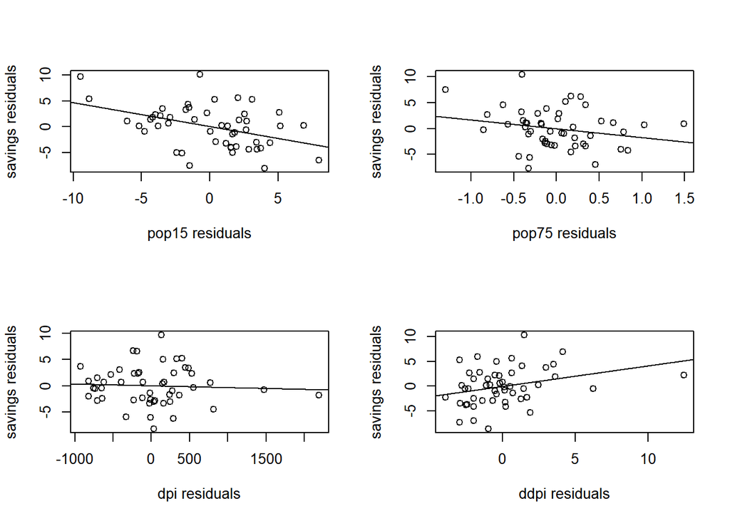

```r
par(mfrow=c(2,2))
plot(r.pop15, r.ypop15, xlab="pop15 residuals", ylab="savings residuals"); abline(tmp1)
plot(r.pop75, r.ypop75, xlab="pop75 residuals", ylab="savings residuals"); abline(tmp2)
plot(r.dpi, r.ydpi, xlab="dpi residuals", ylab="savings residuals"); abline(tmp3)
plot(r.ddpi, r.yddpi, xlab="ddpi residuals", ylab="savings residuals"); abline(tmp4)
```

```r
#dev.off()
```

The slope for the regression lines fitted to the residuals after removing the effect of each variable one-at-a-time, is the same as the regression coefficient for that variable in the full model.

## 3. Finding the Box-Cox transformation

```r
g = lm(sr ~ pop15+pop75+dpi+ddpi, savings)
# We will do a grid search for the maximum of lambda
lambda = seq(-2, 2, length=400); # it doesn't contain zero.
L = NULL;
n =nrow(savings)
# Now loop over the 400 values of lambda and
# record the log-likelihood function
for(i in 1:400){
y=(sr^lambda[i]-1)/lambda[i];
rss = sum(lm(y~pop15+pop75+dpi+ddpi)$res^2);
L = c(L, -(n/2)*log(rss) + (lambda[i]-1)*sum(log(sr)));
}
# Now select lambda that maximizes L
lambda.hat = lambda[L==max(L)]
lambda.hat
```

```
## [1] 0.9573935
```

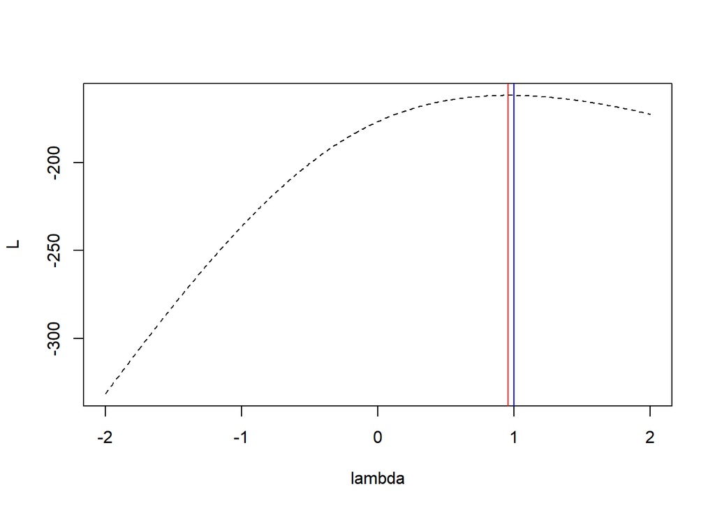

```r
plot(lambda, L, type="n"); lines(lambda, L, lty=2);
abline(v=lambda.hat, col="red"); abline(v=1, col="blue")
```

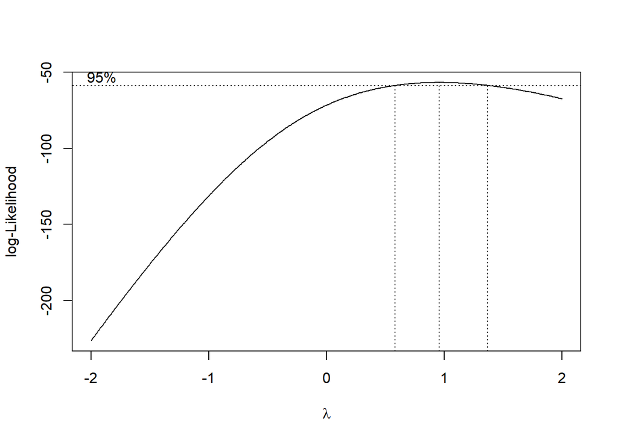

```r
### Use the build-in function in the "MASS" package
library(MASS)
sr.trans=boxcox(g, lambda=seq(-2, 2, length=400))
```

```r
### Use the build-in function in the "MASS" package
names(sr.trans)
```

```
## [1] "x" "y"
```

```r
sr.trans$x[1:10]
```

```
##  [1] -2.000000 -1.989975 -1.979950 -1.969925 -1.959900 -1.949875 -1.939850
##  [8] -1.929825 -1.919799 -1.909774
```

```r
sr.trans$y[1:10]
```

```
##  [1] -226.3535 -225.3027 -224.2532 -223.2052 -222.1585 -221.1133 -220.0694
##  [8] -219.0270 -217.9861 -216.9466
```

```r
sr.trans$x[sr.trans$y == max(sr.trans$y)] # lambda.hat
```

```
## [1] 0.9573935
```

```r
tmp=sr.trans$x[sr.trans$y > max(sr.trans$y) - qchisq(0.95, 1)/2];
range(tmp) # 95% CI. Read Chapter 9 in the Faraway textbook for details.
```

```
## [1] 0.5864662 1.3583960
```

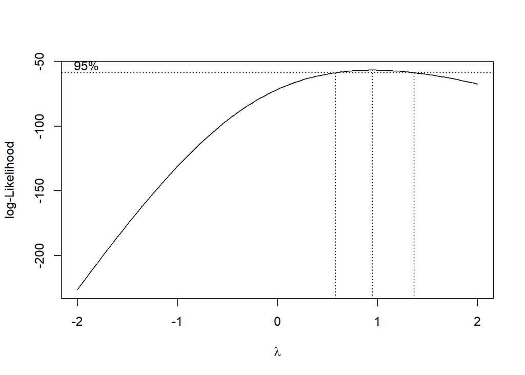

```r
boxcox(g,plotit=T) # plotit=T is the default setting
```

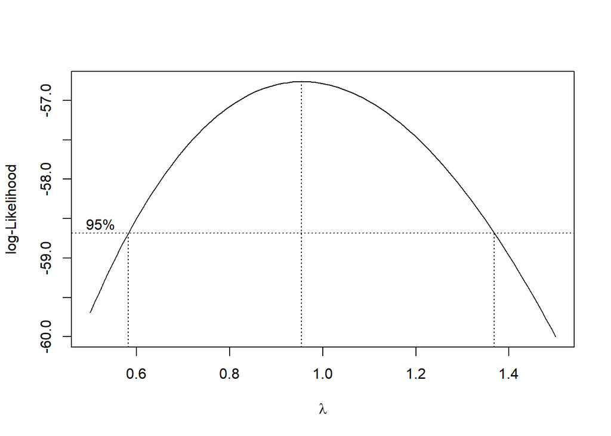

```r
boxcox(g,plotit=T,lambda=seq(0.5,1.5,by=0.1)) # zoom-in
```